# Reproducible Research Project 1

## Introduction

It is now possible to collect a large amount of data about personal movement using activity monitoring devices such as a Fitbit, Nike Fuelband, or Jawbone Up. These type of devices are part of the “quantified self” movement – a group of enthusiasts who take measurements about themselves regularly to improve their health, to find patterns in their behavior, or because they are tech geeks. But these data remain under-utilized both because the raw data are hard to obtain and there is a lack of statistical methods and software for processing and interpreting the data.

This assignment makes use of data from a personal activity monitoring device. This device collects data at 5 minute intervals through out the day. The data consists of two months of data from an anonymous individual collected during the months of October and November, 2012 and include the number of steps taken in 5 minute intervals each day.

The data for this assignment can be downloaded from the course web site:

- Dataset: [Activity monitoring data](https://d396qusza40orc.cloudfront.net/repdata%2Fdata%2Factivity.zip)

The variables included in this dataset are:

steps: Number of steps taking in a 5-minute interval  
date: The date on which the measurement was taken in YYYY-MM-DD format  
interval: Identifier for the 5-minute interval in which measurement was taken  
The dataset is stored in a comma-separated-value (CSV) file and there are a total of 17,568 observations in this dataset.

## Loading and preprocessing the data

```r
library(data.table)
library(ggplot2)
library(dplyr)
fileUrl <- "https://d396qusza40orc.cloudfront.net/repdata%2Fdata%2Factivity.zip"
download.file(fileUrl, destfile = paste0(getwd(), '/repdata%2Fdata%2Factivity.zip'), method = "curl")
unzip("repdata%2Fdata%2Factivity.zip")
```

## Reading csv Data into Data.Table.

```r
activeData <- data.table::fread(input = "activity.csv")
```

## What is total number of steps taken per day?

```r
Total_Steps <- activeData %>%
  group_by(date) %>%
  dplyr::summarize(steps = sum(steps, na.rm=FALSE))

head(Total_Steps,10)
```

```
## # A tibble: 10 x 2
##    date       steps
##    <chr>      <int>
##  1 2012-10-01    NA
##  2 2012-10-02   126
##  3 2012-10-03 11352
##  4 2012-10-04 12116
##  5 2012-10-05 13294
##  6 2012-10-06 15420
##  7 2012-10-07 11015
##  8 2012-10-08    NA
##  9 2012-10-09 12811
## 10 2012-10-10  9900
```

## Histogram of the total number of steps taken each day.

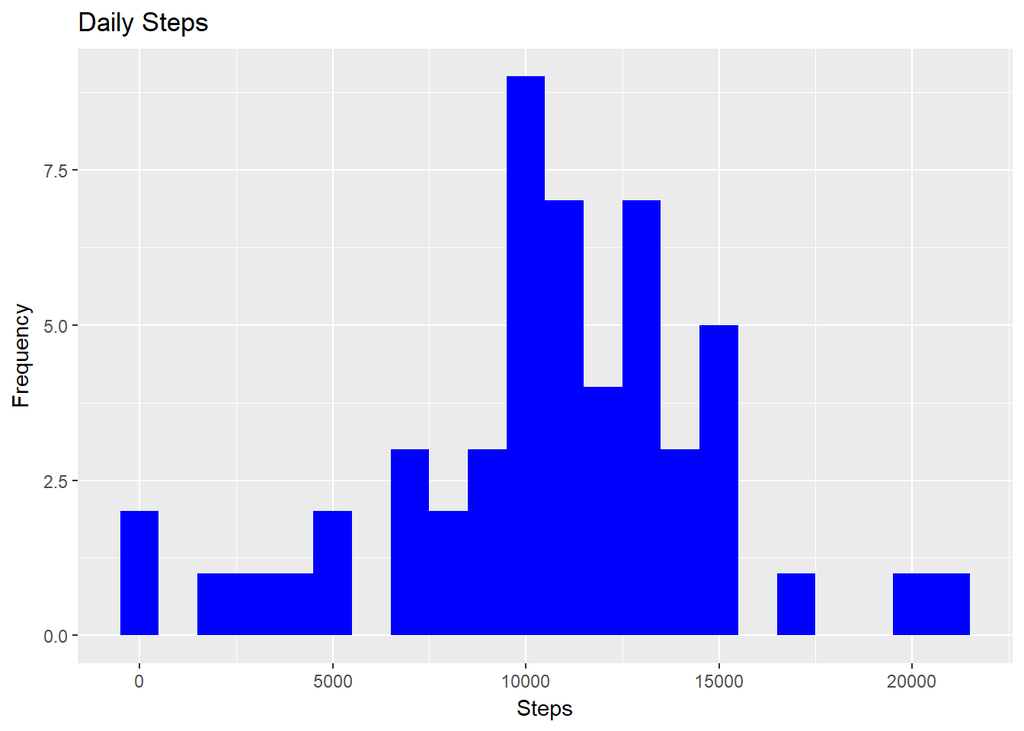

```r
ggplot(Total_Steps, aes(x = steps)) +
  geom_histogram(fill = "blue", binwidth = 1000) +
  labs(title = "Daily Steps", x = "Steps", y = "Frequency")
```

# Calculate and report the mean and median of the total number of steps taken per day.

```r
mean_median <-Total_Steps %>%
  dplyr::summarize(steps_mean = mean(steps, na.rm=TRUE), steps_median = median(steps, na.rm=TRUE))
```

[output not shown]

# What is the average daily activity pattern?

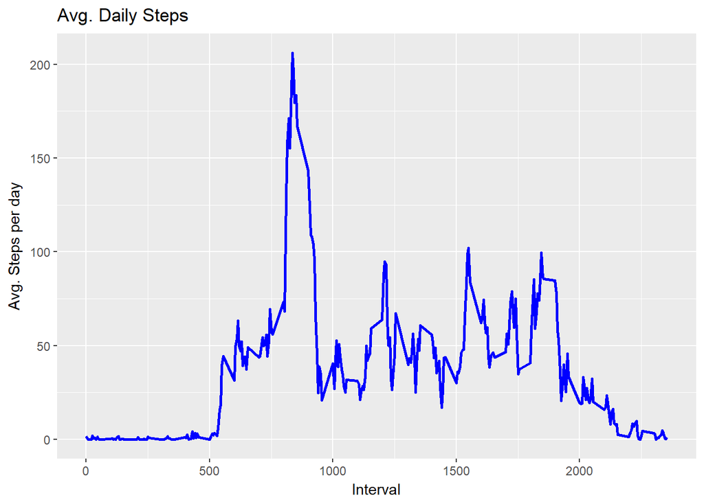

```r
IntervalDT  <- activeData %>%
  group_by(interval) %>%
  dplyr::summarize(steps = mean(steps, na.rm=TRUE))

ggplot(IntervalDT, aes(x =interval , y =steps)) +
  geom_line(color = "blue", size = 1) +
  labs(title = "Avg. Daily Steps", x = "Interval", y = "Avg. Steps per day")
```

# which 5-minute interval, on average across all the days in the dataset, contains the maximum number of steps?

```r
maxIntrval  <- IntervalDT %>%
  filter(steps == max(steps))

maxIntrval
```

```
## # A tibble: 1 x 2
##   interval steps
##      <int> <dbl>
## 1      835  206.
```

[output not shown]

# Calculate and report the total number of missing values in the dataset

```r
Null_value <- sum(is.na(activeData))
Null_value
```

```
## [1] 2304
```

Devise a strategy for filling in all of the missing values in the dataset. The strategy does not need to be sophisticated. For example, you could use the mean/median for that day, or the mean for that 5-minute interval

**I used a strategy for filing in all of the missing values by using ifelse statement , if found null value fill with median of steps and return steps**

```r
activeData$steps <- ifelse(is.na(activeData$steps),
                           ave(activeData$steps, FUN = function(x) median(x,na.rm=TRUE)),
                           activeData$steps)
head(activeData,10)
```

```
##     steps       date interval
##  1:     0 2012-10-01        0
##  2:     0 2012-10-01        5
##  3:     0 2012-10-01       10
##  4:     0 2012-10-01       15
##  5:     0 2012-10-01       20
##  6:     0 2012-10-01       25
##  7:     0 2012-10-01       30
##  8:     0 2012-10-01       35
##  9:     0 2012-10-01       40
## 10:     0 2012-10-01       45
```

```r
# total number of steps taken per day
Total_Steps <- activeData %>%
  group_by(date) %>%
  dplyr::summarize(steps = sum(steps, na.rm=TRUE))
# mean and median total number of steps taken per day

mean_median <-Total_Steps %>%
  dplyr::summarize(steps_mean = mean(steps, na.rm=TRUE), steps_median = median(steps, na.rm=TRUE))
```

[output not shown]

# Are there differences in activity patterns between weekdays and weekends?

Create a new factor variable in the dataset with two levels - “weekday” and “weekend” indicating whether a given date is a weekday or weekend day.

```r
activeData[, date := as.POSIXct(date, format = "%Y-%m-%d")]
activeData[, `Day of Week`:= weekdays(x = date)]
activeData[grepl(pattern = "Monday|Tuesday|Wednesday|Thursday|Friday", x = `Day of Week`), "weekday or weekend"] <- "weekday"
activeData[grepl(pattern = "Saturday|Sunday", x = `Day of Week`), "weekday or weekend"] <- "weekend"
activeData[, `weekday or weekend` := as.factor(`weekday or weekend`)]
head(activeData,10)
```

```
##     steps       date interval Day of Week weekday or weekend
##  1:     0 2012-10-01        0      Monday            weekday
##  2:     0 2012-10-01        5      Monday            weekday
##  3:     0 2012-10-01       10      Monday            weekday
##  4:     0 2012-10-01       15      Monday            weekday
##  5:     0 2012-10-01       20      Monday            weekday
##  6:     0 2012-10-01       25      Monday            weekday
##  7:     0 2012-10-01       30      Monday            weekday
##  8:     0 2012-10-01       35      Monday            weekday
##  9:     0 2012-10-01       40      Monday            weekday
## 10:     0 2012-10-01       45      Monday            weekday
```

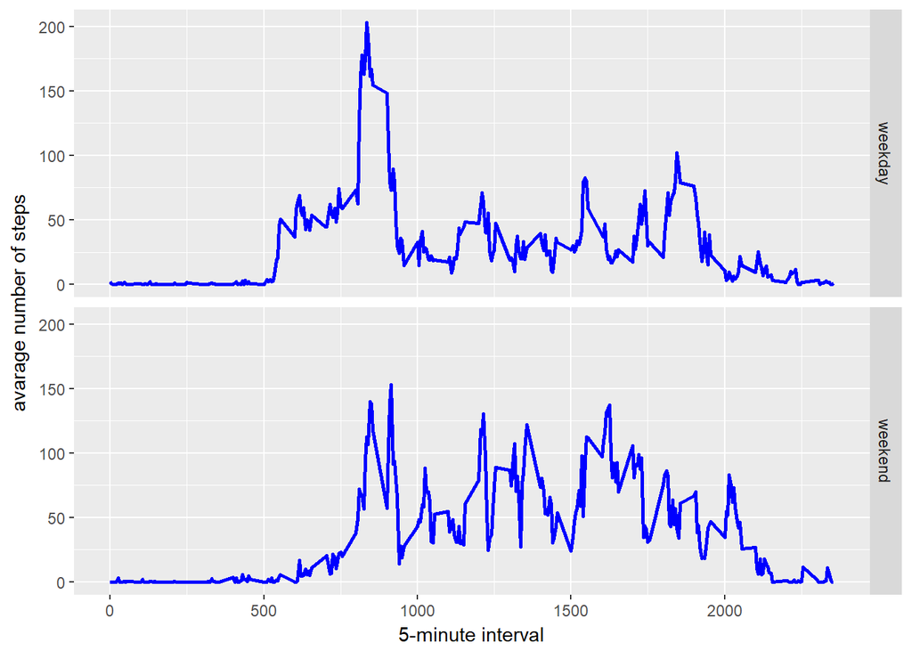

```r
avarge_steps<- aggregate(steps ~ interval + `weekday or weekend`, data=activeData,mean)
ggplot(avarge_steps, aes(x =interval , y =steps)) +
  geom_line(color = "Blue", size = 1) +
  facet_grid(`weekday or weekend` ~ .) +
  xlab("5-minute interval") +
  ylab("avarage number of steps")
```